# Habits of Non-Verbal Intimacy: Reducing the Number of Dimensions Using Factor Analysis

This project is based on an analysis I did for my honors thesis in neuroscience: analyzing non-verbal behavior in a sample of depressed patients over 6 months of treatment. I had collected data on the frequencies of a number of non-verbal behaviors, and I wished to reduce the number of variables before performing furhter analysis.

Factor analysis uncovers latent dimensions or “factors” from a large number of related variables. It can be used to reveal insights about which variables group together through positive and negative correlations.

Since my original dataset contains sensitive patient data, I used here results from the Nonverbal Immediacy Scale from Open Psychometrics. This data is in the format of survey ratings in which the respondants say how often they perform an action (never, rarely, occasionally, often, very often). This Likert-type data is widely encountered in psychology and market research. In these contexts, factor analysis is a useful tool for translating numerous responses into generalizable constructs and actional inferences (e.g. about a consumer’s likelihood to display a certain type of behavior or buy a certain type of product).

## Setup

### Dowload the data

```r
#loads the data into the workspace
messy_data<-read.delim("NIS_data/data.csv", na.strings = c("", "NA"))
```

## Clean the data

The messy dataset contains NIS measures as well as demographic, ten item personality inventory, and word checks.

The word checks can be used to determine responses that aren’t reliable (perhaps a person was not answering the survey thoughtfully or wasn’t paying attention)

The following code possibly invalid responses, and retaining only the data of interest (the question ratings).

```r
NIS_clean<-messy_data[1:5000, ]%>% #take just the first 5,000 observations of this massive dataset
  select(c("Q1", "Q2", "Q3","Q4", "Q5", "Q6", "Q7",  "Q8",  "Q9",  "Q10", "Q11", "Q12", "Q13", "Q14", "Q15", "Q16", "Q17", "Q18", "Q19", "Q20", "Q21", "Q22", "Q23", "Q24", "Q25", "Q26", "VCL1", "VCL2", "VCL3", "VCL4", "VCL5", "VCL6", "VCL7", "VCL8", "VCL9",  "VCL10",  "VCL11", "VCL12",  "VCL13", "VCL14", "VCL15",  "VCL16"))%>% #select the actual columns, as well as the word recognition columns
  filter_at(vars(c("VCL6", "VCL9","VCL12")), all_vars(.==0))%>% #these three variables are not real words. This keeps only observations where only all three were marked as unknown.
  filter_at(vars(starts_with("Q")), all_vars(.!=0))%>% #0 is not a valid option in the 1-5 likert scale for NIS items. This keeps only observations where none of the Qs were answered with 0.
  select(starts_with("Q"))%>% #retains only the NIS questions
  mutate_all(as.numeric)
```

This assesses the multivariate normality of the data. Data is not normallly distributed, which means we have to use Principal axis factoring method.

| Test | HZ | p value | MVN |
| --- | --- | --- | --- |
| Henze-Zirkler | 104 | 0 | NO |

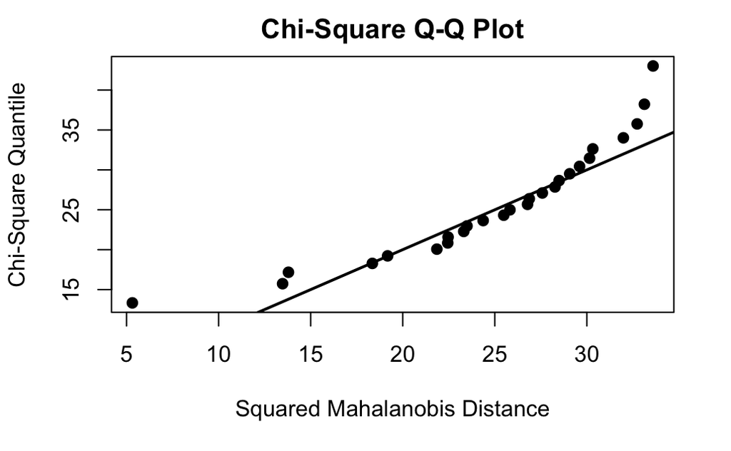

They aren’t normally distributed (which isnt surprising since this a likert scale dataset) Therefore, pincipal axis method of extracting factors should be used

## Now we are ready to run factor analysis

Because we are working with Likert rating data, we use the polychoric correlation matrix. Polychoric correlations estimate the theorized correlations between pairs of ordinal variables. This matrix will be used in place of a correlation matrix in the factor analysis.

```r
NIS_m<-data.matrix(NIS_clean) #save data as matrix
pcor<-polycor::hetcor(NIS_m, ML = T)$correlations #extract the polychoric correlation matrix
```

### How many factors?

To determine how many factors to extract, parallel analysis compares the scree polt of successive eigenvalues of the observed data to a random matrix of the same size.

```
Parallel analysis suggests that the number of factors =  8  and the number of components =  NA
```

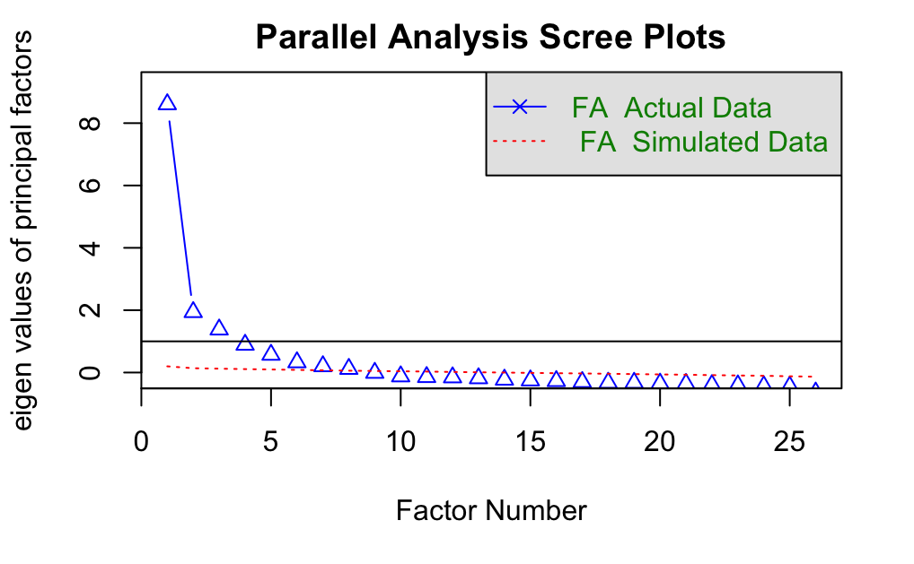

```r
psych::fa.parallel(pcor, n.obs = 3633, fm = "pa", fa = "fa")
```

The following code performs and prints the factor analysis. - The factor method is Principal Axis (“pa”). This method is best for non-normally distributed data. - The rotation is “oblimin”, a standard oblique rotation, meaning that the it allows the extracted factors to be correlated with each other. I chose “oblimin” because factors in this dataset are all related to a common construct and are likely to be correlated. The purpose of rotations is to “obtain simple structure in order to enhance interpretability of the solution” (Norris).

```r
fac <- psych::fa(pcor, nfactors=8, fm="pa", n.obs=3633, rotate="oblimin")
```

## Is the model a good fit for the data?

```r
print(paste("Root mean square of the residuals:", fac$rms))
```

```
[1] "Root mean square of the residuals: 0.0127687756278522"
```

```r
print(paste("Tucker Lewis index:", fac$TLI))
```

```
[1] "Tucker Lewis index: 0.953175097873621"
```

```r
print(paste("RMSEA:", fac$RMSEA[1]))
```

```
[1] "RMSEA: 0.0469462560124029"
```

The above model is a good fit: root mean square of residuals is close to 0, the Tucker Lewis index is close to 1, and RMSEA index is < 0.05.

## Interpreting the factor analysis

Next I explored which questions ended up in which factor.

The following code saves the loadings to a dataFrame and renames the columns.

```r
fa_loadings <- fac$loadings%>%
  as.table()%>%
  as.data.frame()%>%
  filter(Freq>=0.3 | Freq<=-0.3)
colnames(fa_loadings)<-c("Question", "Factor", "Loading")
levels(fa_loadings$Factor)<-c("PA1","PA2","PA3","PA4","PA5","PA6","PA7","PA8")
```

This sets up a list that allows you to find the text of each question using questions$questionNumber

```r
#set up empty list:
questions<-vector(mode = "list", length =26)
#set up an empty list of names:
qnames<-vector(mode = "character", length = 26)
#read in the the part of the codebook that lists the questions to a temporary file:
temp<-readLines("../NIS_data/codebook.txt")[9:34]
#the first item of each line in temp is the question # and the 2nd item is the question text:
for (i in 1:26){
  qnames[i]<-strsplit(temp[i], '\t')[[1]][1]
  questions[i]<-strsplit(temp[i], '\t')[[1]][2]
  names(questions)<-qnames
}
#example:
questions$Q16
```

```
[1] "I move closer to people when I talk to them. "
```

This adds a column to the fa_loadings DataFrame that is the text of each question.

```r
fa_loadings$Question_txt<-factor(NA,levels = c(
  "I use my hands and arms to gesture while talking to people. ",
  "I touch others on the shoulder or arm while talking to them. ",
  "I use a monotone or dull voice while talking to people. ",
  "I look over or away from others while talking to them. ",
  "I move away from others when they touch me while we are talking. ",
  "I have a relaxed body position when I talk to people. ",
  "I frown while talking to people. ",
  "I avoid eye contact while talking to people. ",
  "I have a tense body position while talking to people. ",
  "I sit close or stand close to people while talking with them. ",
  "My voice is monotonous or dull when I talk to people. ",
  "I use a variety of vocal expressions when I talk to people. ",
  "I gesture when I talk to people. ",
  "I am animated when I talk to people. ",
  "I have a bland facial expression when I talk to people. ",
  "I move closer to people when I talk to them. ",
  "I look directly at people while talking to them. ",
  "I am stiff when I talk to people. ",
  "I have a lot of vocal variety when I talk to people. ",
  "I avoid gesturing while I am talking to people. ",
  "I lean toward people when I talk to them. ",
  "I maintain eye contact with people when I talk to them. ",
  "I try not to sit or stand close to people when I talk with them. ",
  "I lean away from people when I talk to them. ",
  "I smile when I talk to people. ",
  "I avoid touching people when I talk to them."))
for (i in unique(fa_loadings$Question)){
  fa_loadings$Question_txt[fa_loadings$Question==i]<-as.character(questions[i])
}
fa_loadings<-arrange(fa_loadings, Factor)
head(fa_loadings)
```

|  | Question | Factor | Loading | Question_txt |
| --- | --- | --- | --- | --- |
| 1 | Q4 | PA1 | -0.7489260 | I look over or away from others while talking to them. |
| 2 | Q8 | PA1 | -0.8678804 | I avoid eye contact while talking to people. |
| 3 | Q17 | PA1 | 0.8647455 | I look directly at people while talking to them. |
| 4 | Q22 | PA1 | 0.8986929 | I maintain eye contact with people when I talk to them. |
| 5 | Q1 | PA2 | 0.9084591 | I use my hands and arms to gesture while talking to people. |
| 6 | Q13 | PA2 | 0.9226433 | I gesture when I talk to people. |

## Visualize the factor loadings

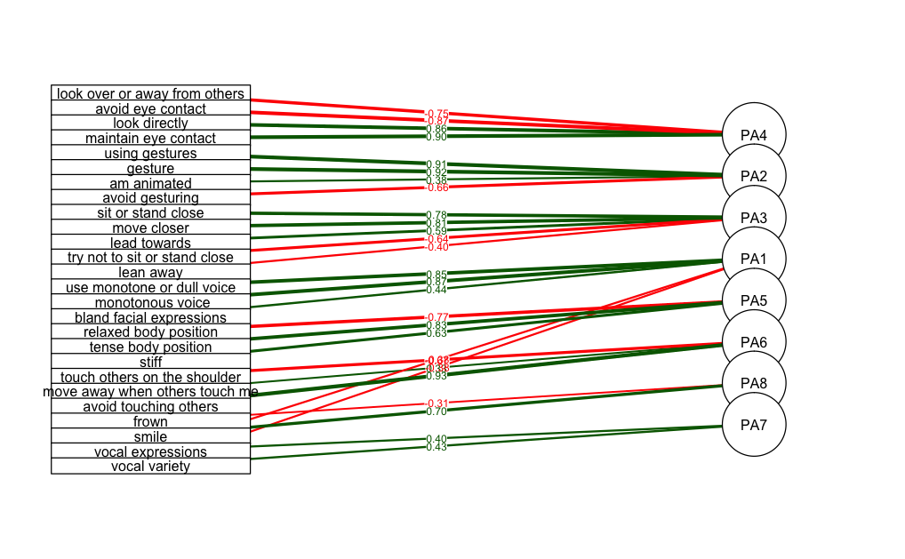

```r
model<-semPlot::semPlotModel(fac$loadings)
semPlot::semPaths(model,
                  what="par",
                  whatLabels="est",
                  rotation=4,
                  minimum=0.3,
                  sizeMan=25,
                  sizeMan2 = 2,
                  edge.width =.3,
                  nodeLabels = c("look over or away from others", "avoid eye contact", "look directly", "maintain eye contact", "using gestures", "gesture", "am animated", "avoid gesturing", "sit or stand close", "move closer", "lead towards", "try not to sit or stand close", "lean away","use monotone or dull voice" ," monotonous voice", "bland facial expressions","relaxed body position", "tense body position","stiff","touch others on the shoulder", "move away when others touch me", "avoid touching others", "frown", "smile", "vocal expressions", "vocal variety", "PA4", "PA2", "PA3","PA1", "PA5", "PA6", "PA8", "PA7"),
                  label.cex=(.5),
                  label.scale=F)
```